# One Line Plot - Points and Lines

Walter Xie

09/02/2017

```r
library(gg1L)
#getwd()
```

## Scatter plot

Create random coordinates for 2 clusters:

```r
df.clusters <- random2Clusters()
df.clusters$labels <- rownames(df.clusters)
df.clusters[1:3,]
```

```
##          x        y group labels
## 1 1.673964 2.437651     A      1
## 2 2.552462 1.928776     A      2
## 3 1.325056 4.163509     A      3
```

Scatter plots may have overlaps between data points and axises. `unclip.ggplot` can turns off clipping, but it returns a *gtable* object, so that either `pdf.gtplot` or `plotgt` will be used to handle the plot.

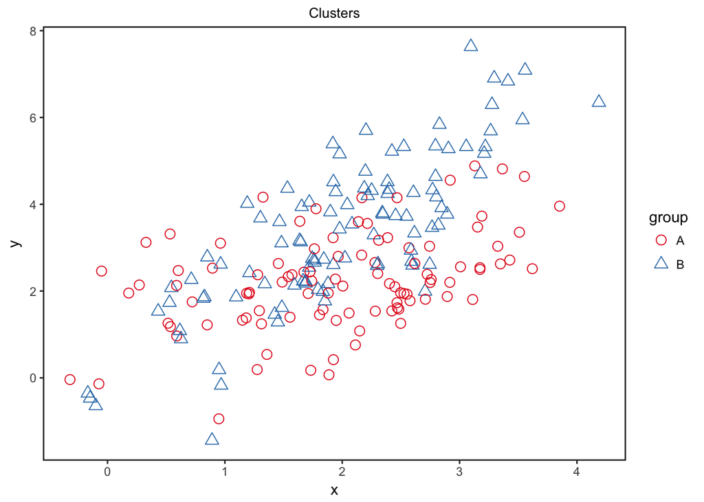

```r
gg.plot <- ggScatterPlot(df.clusters, x.id="x", y.id="y", colour.id="group", shape.id="group",
                         title="Clusters", palette="Set1", verbose=F)
# turns off clipping
g.table <- unclip.ggplot(gg.plot)
plotgt(g.table)
```

### Some tricks

Add `expand_limits` after ggplot object to expend x and y axes:

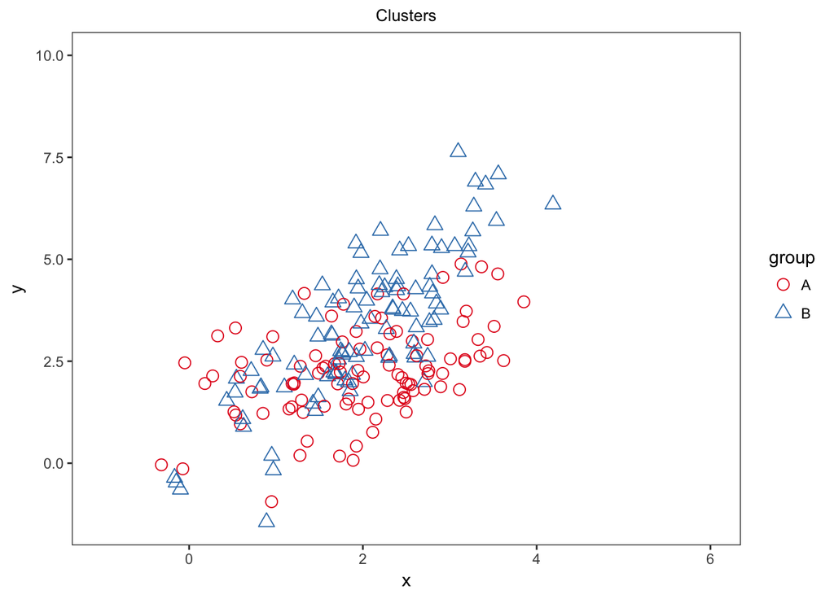

```r
gg.plot + expand_limits(x = c(-1, 6), y=c(-1, 10))
```

`ellipsed.id=“group”` creates ellipses by groups, `text.id=“labels”` defines the column for labels, `xintercept=0 and yintercept=0` sets the coordinate axes, and `text.data=subset(df.clusters, x > 3 & y > 6)` selectively labels the points at x > 3 and y > 6:

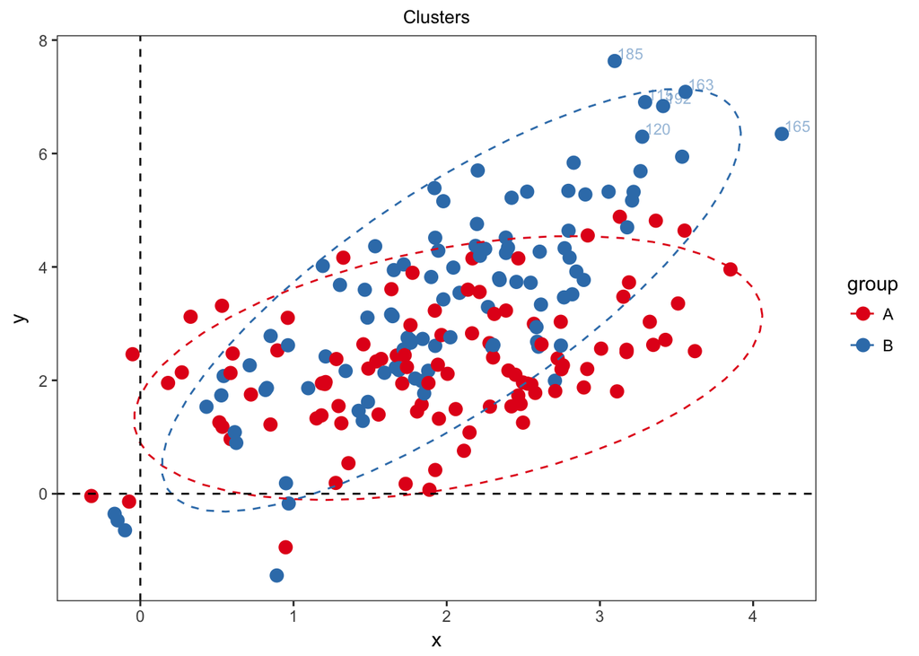

```r
ggScatterPlot(df.clusters, x.id="x", y.id="y", colour.id="group", ellipsed.id="group", text.id="labels",
              text.data=subset(df.clusters, x > 3 & y > 6), xintercept=0, yintercept=0,
              title="Clusters", palette="Set1", verbose=F)
```

`text.or.point` controls appearance of labels and points:

- if 1, then display the texts only;
- if 2, then only points;
- if 3, the default, then both the texts and points.

For example, show only labels:

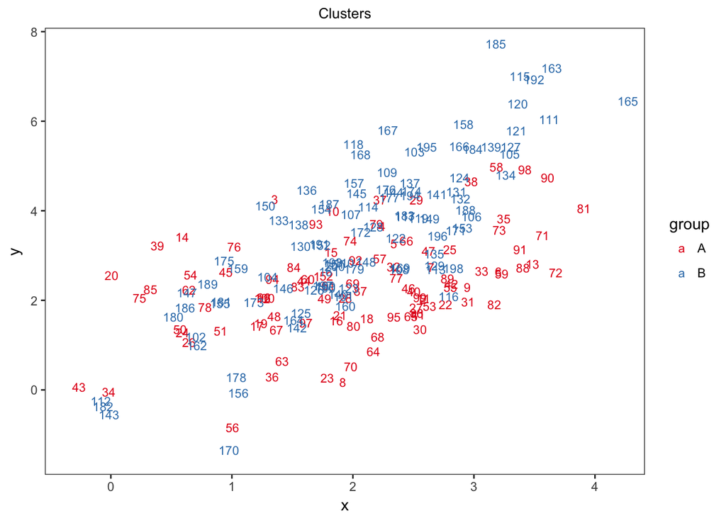

```r
ggScatterPlot(df.clusters, x.id="x", y.id="y", colour.id="group", text.id="labels",
              text.or.point=1, title="Clusters", palette="Set1", verbose=F)
```

`text.repel` uses *geom_text_repel* from *ggrepel* package to avoid overlapped texts. It is better than `text.avoid.overlap`, where the latter sometime removes overlapped texts.

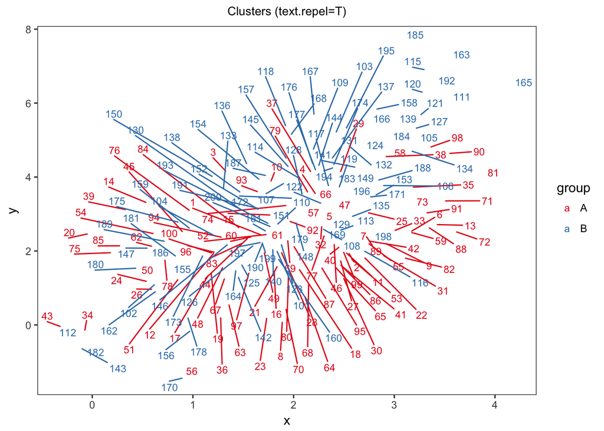

```r
ggScatterPlot(df.clusters, x.id="x", y.id="y", colour.id="group", text.id="labels",
              text.or.point=1, text.repel=T, title="Clusters (text.repel=T)",
              palette="Set1", verbose=F)
```

`text.avoid.overlap` uses *check_overlap* in *geom_text* from *ggplot2* package:

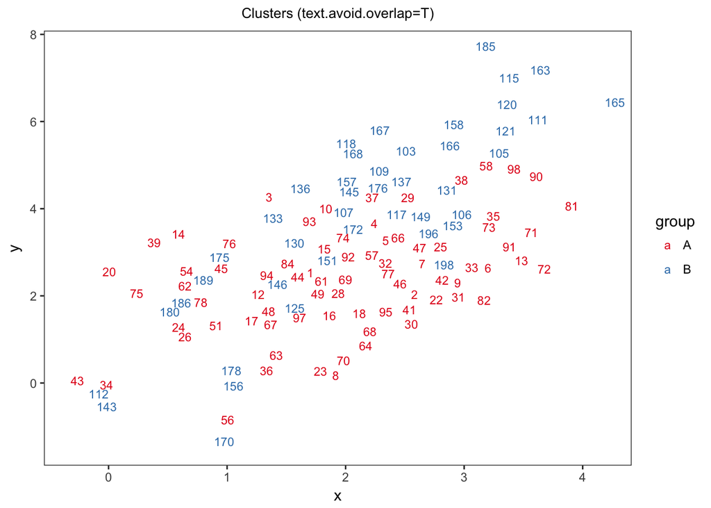

```r
ggScatterPlot(df.clusters, x.id="x", y.id="y", colour.id="group", text.id="labels",
              text.or.point=1, text.avoid.overlap=T, title="Clusters (text.avoid.overlap=T)",
              palette="Set1", verbose=F)
```

## Non-metric multidimensional scaling

Load the example data *reads.phyla*, where *x* is one of genetic marks, and the numbers are eDNA sequences (reads) identified as the phylum listed in *y*:

```r
data(reads.phyla)
reads.phyla[1:2,]
```

```
##                16S 18S trnL ITS COI COI-spun TaxaGroup
## Actinobacteria 958   1  301   4   7        0  Bacteria
## Aquificae        0   0   10   0   0        0  Bacteria
```

Because the functions to compute NMDS *metaMDS*, PCoA *cmdscale*, and PCA *prcomp* take different input data, please make sure you give a valid input for different NMDS plots.

### NMDS using *metaMDS*

The following Nonmetric Multidimensional Scaling (NMDS) plot illustrates how the phyla are different in term of their reads abundances in 6 markers, and the data frame `reads.phyla[,7, drop=F]` provides the groups used for colouring texts.

```r
nmds <- gtNMDSPlot(reads.phyla[,1:6], reads.phyla[,7, drop=F], colour.id="TaxaGroup",
                   text.or.point=2, verbose=F)
```

```
## Square root transformation
## Wisconsin double standardization
## *** No convergence -- monoMDS stopping criteria:
##     15: stress ratio > sratmax
##      5: scale factor of the gradient < sfgrmin
```

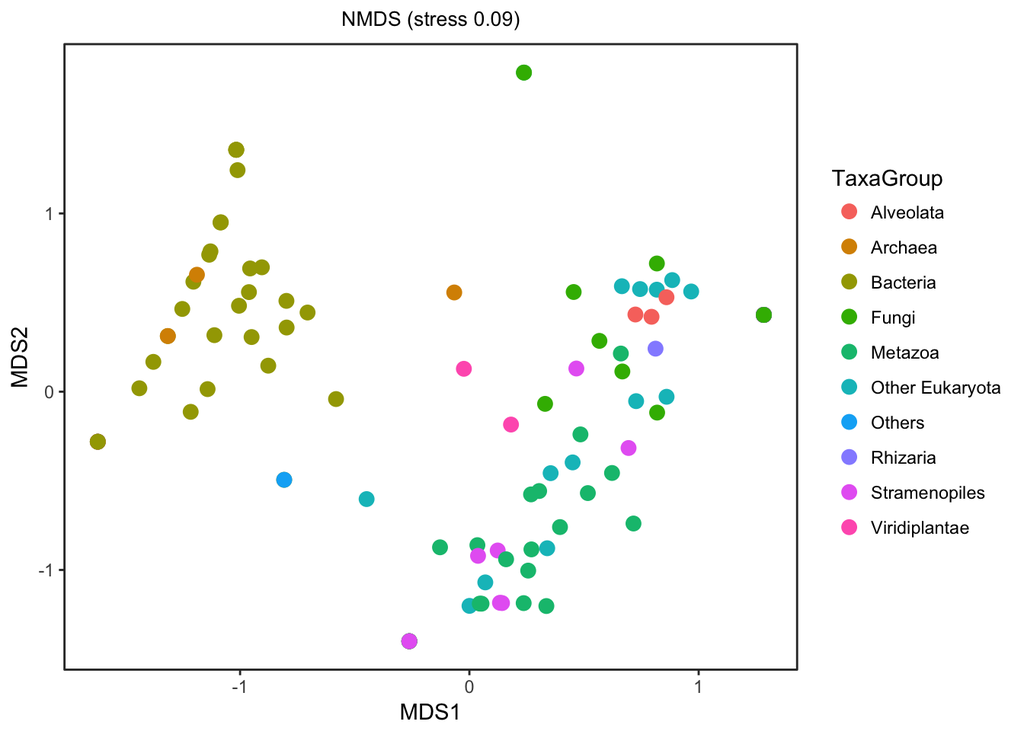

```r
plotgt(nmds)
```

### PCoA using *cmdscale*

It is a classical MDS and also known as principal coordinates analysis PCoA (Gower, 1966).

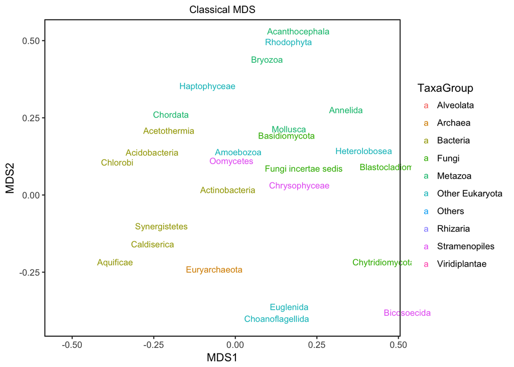

```r
require(vegan)
dist.cm <- vegdist(reads.phyla[,1:6], method="jaccard", binary=TRUE)
cmds <- gtPCoAPlot(dist.cm, reads.phyla[,7, drop=F], colour.id="TaxaGroup",
                   text.or.point=1, text.avoid.overlap=T, verbose=F)
plotgt(cmds)
```

### PCA using *prcomp*

`prcomp` rotates the input to analyse on columns, so that we have the plot of 6 markers whose differences are in term of the abundances of phyla,

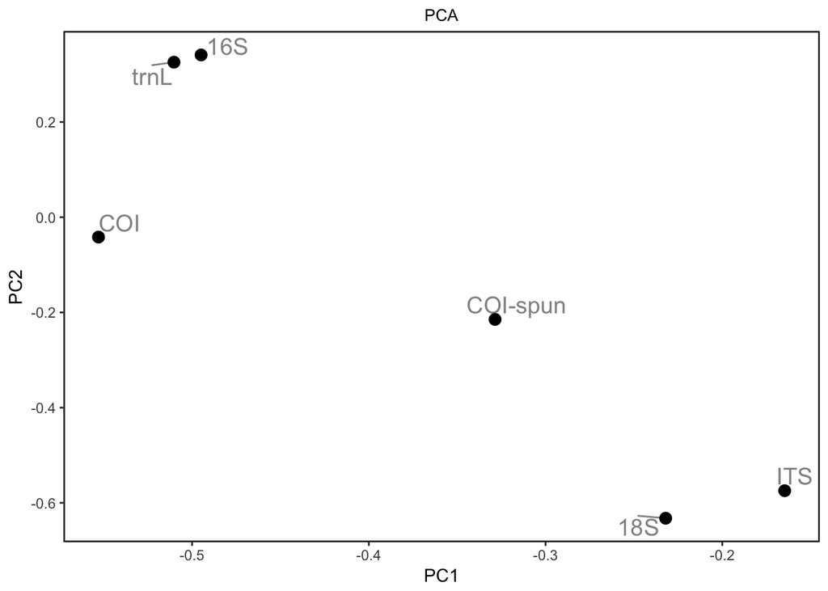

```r
pca <- gtPCAPlot(reads.phyla[,1:6], text.or.point=3, text.size=5, text.repel=T, verbose=F)
plotgt(pca)
```

## Line with points

The basic tutorial of line with points is avaible in another tutorial [**Plot traces**](https://cdn.rawgit.com/walterxie/gg1L/master/tutorials/OneLinePlotTracerR.html) subsection.